# **Kyle's Findings - Deep Learning Convolutional Neural Network Capstone:**

- Facial Emotion Detection using Supervised Learning Image Analysis Capstone Project

## **Executive Summary**

**Key Takeaways:**

- **identify and focus on the big picture first and all of its components**
  - This notebook explores multiple configurations of basic neural networks, transfer learning approaches, and deep complex neural networks are designed, trained, and tested.
  - These models are being trained and designed to recognize and correctly predict human emotional facial expressions as low-res grayscale images.
  - My approach to the model building was to decrease the filter count as the network deepened. My intuition was to start with many filters to catch as many potential features as possible early. As the model deepens the filter count reduces to provide more nuanced understanding of the data in the network.
  - Minimal MaxPooling utilization because data images are so small, reducing their feature complexity wouldn't be helpful.
  - Minimal Dropout utilization, overfitting is addressed through early stopping. The size of the datasets already makes training tricky. More photos needs to be in the training set, dropout in this instance is a reduction in data that is needed. Address overfitting another way.
- **summarize the most imporant findings and takeaways in the beginning**
  - Overfit models occur often with neural networks, boundaries must be set up when training and running a model to prevent overfitting.
  - I A/B tested the grayscale vs RGB on the same model, only changed the color mode. The rgb color mode model scored nearly 4% lower than the grayscale model.
- **provide the final proposed model specifications**
  - The final proposed model is the Fine-Tuned EfficientNet Model that was trained on the output of a 1st frozen EfficientNet Model.
  - The 1st model utilizes the EfficientNet training weights as they are and I add an ANN to this model to produce the facial expression class prediction.
  - This final model is the 1st model but the last 40 layers of the transferred network are unfrozen and allowed to train on the dataset in this project.
  - This transferred network was initially trained on a massive database of many different images beyond faces. By allowing a portion of the transferred layers to be trained on our data helps the model focus on the specific data patterns associated with faces.

**Key Next Steps:**

- **steps that can be taken to improve the solution**
  - Best next step to improve any data driven solution is to review the data, it's labels, and add more photographic examples to train on.
  - Further exploration of model configurations, transfer model modifications, and application of data augmentation to help expand the dataset.
  - Explore ability to further divide the photographs into more categories. This would provide a method to help the model identify the subtle differences between facial expressions. Too few classes misses important nuances in the data and too easily miscategorizes.
- **how to make the best of the solution**
  - To make the best of this solution, newly introduced datasets must be preprocessed in the same way as done for the initial training set.
  - Understand that the most commonly mis-identification are between 'happy' and 'neutral'. No immediate negative outcomes from this mix-up are apparent and to be avoided.
- **what are the steps to be followed by the stakeholders**
  - The model performs well enough to deploy into the wild. The shortcommings of mixing up happy and neutral wont cause pain, loss, damage, or anything else that should be avoided.
  - As with most tools, this tool's shortcomings can be overcome by pairing this tool with other data to help fully contextualize the perceived facial expressions.
  - Use this tool as a launchpad to continue development and refinement of the model to continue to increase the effectiveness of the model over time.

## **Problem & Solution Summary:**

**what problem is being solved**

- The problem is determining if its possible to train a computer to accurately predict human emotions through facial expressions observed in low resolution grayscale images.

**final proposed solution design**

- The final proposed solution's design is built on a series of EfficientNet Transfer Learning models:
- The first model's transfered layers do not train while my additional layers will train on the transfered model's weights.
- The second model utilizes the first model's output as input data. Define a function to unfreeze the last 40 layers of the model, allowing them to train further. The learning rate is reduced to facilitate the model's fine-tuning.

**why is this a 'valid' solution that is likely to solve the problem**

- the reason for the proposed solution design
  - The proposed solution's accuracy of 75% & loss of 0.6131 are good performance numbers. This model is delployable & the miscategorizations are low. The pairing of 'happy' and 'neutral' performed worst, luckily these misclassifications are of little consequence.
  - Deployment allows utilization of the model's capabilities and advantages without big risks while solutions for the happy/neutral problem are engineered.
- how does it affect the problem/business
  - The ability to recognize human emotions via facial expressions in low resolution grayscale imagery can be incredibly valuable information.
  - For example, retail businesses can utilize this model to non-verbally survey customer emotions as they enter, shop, and leave.

## **Recommendations for Implementation:**

**what are some key recommendations to implement the solution**

- This solution is just a tool. It is not a 1-size-fits-all solution machine, and no single tool can do an entire job on its own.
- Additional training runs will improve the model's performance.
- This model is designed to observe single images of a particular aspect ratio. Any problems with data outside these parameters need to be altered or a new model must be instantiated.

**what are the key actionables for stakeholders**

- Continue to collect new data to use while maintaining a routine training schedule to steadily improve the model's performance.
- Readings of 'happy' or 'neutral' emotions need extra scrutiny since they were the most difficult for the model to predict correctly.
- Model is deployable, ready for new images to be input for predictions.

**what is the expected benefit and/or costs**

- list the benefits of the solution
  - Humans communicate a lot through their faces and a computer that is able to accurately detect a human's emotion could react to the humans reaction during an interaction.
  - Unbiased customer survey of each moment they are in the store, facial expression emotion detection is good for this.
  - Unbiased employee emotion detection could help identify potential trouble, under/over worked, and many other things
  - A big cost to many is privacy. Constant filming of faces, data collected for training runs, the monitoring of actions for interpretation.
- take some rational assumptions to put forward some numbers on costs/benefits for stakeholders
  - Short Term costs to integrate the new tool into current infrastructure and workflow.
  - Additional job position that needs employee to collect and maintain integrity of the production model.

**what are the key risks and challenges**

- what are the potential risks or challenges of the proposed solution design
  - Biggest risk of any prediction model is poor predictions producing bad outcomes. Steady upkeep and additional data for the model will help avoid these errors.
  - Having the input data required to be a certain size requires time-consuming data preprocessing before the model sees it.

**what further analysis needs to be done or what other associated problems need to be solved**

- More analysis of the network architecture configurations would help discover more effective model designs.
- More photographs of faces, properly labeled, to train the model even more.
- Divide up vauge emotions like 'neutral' into seperate groups of more subtle and direct emotions, i.e. fear, disgust, bored, intese, etc...
- Taking the analysis of still images to interpret human emotions is a limited tool, iterating this tool for use in video and eventually into live-feed camera footage.
- The model's restrict requirement of a certain aspect ratio is another limitation. Developing this tool and technique into a model that accepts any aspect ratio would be a powerful next step.

# **Facial Emotion Detection Full Analysis**

## **Problem Definition**

**The context:** Why is this problem important to solve?

- The problem of identifying human facial emotions is an extremely important foundational function for any face tracking technologies. If only 1 emotion is considered a face then when a new emotional expression is observed by the computer it will not be registered as a face.

**The objectives:** What is the intended goal?

- Additional and more nuanced reasons for being able to determine facial expressions can be incorporated into technologies that register unspoken communications, like a system that can track faces and emotions for customers as they enter the store, browse, and ultimately leave. Could be interesting data that could go undetected in a proper survey.

**The key questions:** What are the key questions that need to be answered?

- Can a neural network structure really be able to see and interpret facial expression at all?
- How many images and classified emotions are needed to make a robust and broad performing model?
- What is the best approach to getting high performance results, build model's from scratch or utilize transfer learning to build on the work of past model training.

**The problem formulation:** What are we trying to solve using data science?

- Through data science we are trying to interpret the patterns of pixel shades of many different images to be able to accurately recognize when an image is of a face with a certain expression.

## **About the dataset**

The data set consists of 3 folders, i.e., 'test', 'train', and 'validation'. Each of these folders has four subfolders:

**‘happy’**: Images of people who have happy facial expressions.  
**‘sad’**: Images of people with sad or upset facial expressions.  
**‘surprise’**: Images of people who have shocked or surprised facial expressions.  
**‘neutral’**: Images of people showing no prominent emotion in their facial expression at all.

## **Mounting the Drive**

**NOTE:** Please use Google Colab from your browser for this notebook. **Google.colab is NOT a library that can be downloaded locally on your device.**

```python
from google.colab import drive
drive.mount('/content/disc/')
```

## **Importing the Libraries**

```python
# For Data Preprocessing
import pandas as pd
import numpy as np


# For Data Visualization
import matplotlib.pyplot as plt
import seaborn as sns
import cv2

# For working with a zip file
import zipfile
import os

# For Model Building
import tensorflow as tf
import keras
from keras import layers
from tensorflow.keras.applications.vgg16 import VGG16
from tensorflow.keras.models import Sequential, Model
from tensorflow.keras.layers import Dense, Dropout, Flatten
from tensorflow.keras.layers import Conv2D, MaxPooling2D, BatchNormalization, Activation, Input, LeakyReLU, Activation
from tensorflow.keras import backend
from tensorflow.keras.utils import to_categorical
from tensorflow.keras.optimizers import RMSprop, Adam, SGD
from tensorflow.keras.callbacks import EarlyStopping
from tensorflow.keras.callbacks import ModelCheckpoint
from tensorflow.keras import losses, optimizers
from tensorflow.keras.preprocessing.image import load_img, ImageDataGenerator
from google.colab.patches import cv2_imshow

import h5py
h5py.run_tests()
```

```
1
```

#### **Load and unzip the data**

**Note:**

- You must download the dataset from the link provided on Olympus and upload the same on your Google drive before executing the code in the next cell.
- In case of any error, please make sure that the path of the file is correct as the path may be different for you.

```python
path = '/content/disc/MyDrive/Ky/Applied Data Science/DataSets/Facial_emotion_images.zip'

# extract files from the .zip file
with zipfile.ZipFile(path, 'r') as zip_ref:
    zip_ref.extractall()
```

```python
DATADIR = '/content/Facial_emotion_images/train'
DATADIR_test = '/content/Facial_emotion_images/test'
DATADIR_validation = '/content/Facial_emotion_images/validation'
CATEGORIES = ['happy', 'neutral', 'sad', 'surprise']
IMG_SIZE = 48

folder_path = 'Facial_emotion_images/'
```

#### **Prep the Data**

Since the dataset has multiple subfolders I want to set up a few variables and feature names before beginning.

```python
# Here I am going to define a function to extract the images from the dataset
training_data = []

def make_training_data():
  for category in CATEGORIES:
    path = os.path.join(DATADIR, category)
    classifier_number = category

    for img in os.listdir(path):
      array01 = cv2.imread(os.path.join(path, img))
      array02 = cv2.resize(array01, (IMG_SIZE, IMG_SIZE))
      training_data.append([array02, classifier_number])

make_training_data()

# make test data

test_data = []

def make_test_data():
  for category in CATEGORIES:
    path = os.path.join(DATADIR_test, category)
    classifier_number = category

    for img in os.listdir(path):
      array01_test = cv2.imread(os.path.join(path, img))
      array02_test = cv2.resize(array01_test, (IMG_SIZE, IMG_SIZE))
      test_data.append([array02_test, classifier_number])

make_test_data()

# make validation data

validation_data = []

def make_validation_data():
  for category in CATEGORIES:
    path = os.path.join(DATADIR_validation, category)
    classifier_number = category

    for img in os.listdir(path):
      array01_validation = cv2.imread(os.path.join(path, img))
      array02_validation = cv2.resize(array01_validation, (IMG_SIZE, IMG_SIZE))
      validation_data.append([array02_validation, classifier_number])

make_validation_data()
```

#### **More Data Preprocessing**

- Create seperate lists to store the numpy arrays and their labels for both the train and test sets.
- Convert the features into arrays, and the labels into DataFrames

#### seperate target variable from independent variables

```python
X_train = []
y_train = []

np.random.shuffle(training_data)
for features, label in training_data:
  X_train.append(features)
  y_train.append(label)
```

```python
X_test = []
y_test = []

np.random.shuffle(test_data)
for features, label in test_data:
  X_test.append(features)
  y_test.append(label)
```

```python
X_val = []
y_val = []

np.random.shuffle(validation_data)
for features, label in validation_data:
  X_val.append(features)
  y_val.append(label)
```

```python
X_train = np.array(X_train)
X_test = np.array(X_test)
X_val = np.array(X_val)
X_train.shape
```

```
(15109, 48, 48, 3)
```

```python
# convert Labels into a dataframe

y_train = pd.DataFrame(y_train, columns = ['Label'], dtype = object)
y_test = pd.DataFrame(y_test, columns = ['Label'], dtype = object)
y_val = pd.DataFrame(y_val, columns = ['Label'], dtype = object)
```

#### **Normalize the input data**

It helps with the neural network.

```python
# divide the image data by 255 to standardize the values of the pixels
X_train_normalized = X_train/255.0

X_test_normalized = X_test/255.0

X_val_normalized = X_val/255.0

X_train_normalized.shape
```

```
(15109, 48, 48, 3)
```

#### **Encode Target Variable**

```python
# target variable distribution
y_train.value_counts()
```

```
Label
sad         3982
neutral     3978
happy       3976
surprise    3173
dtype: int64
```

```python
# encoding target variable

y_train_encoded = []

for label_name in y_train['Label']:
    if(label_name == 'sad'):
      y_train_encoded.append(0)

    if(label_name == 'neutral'):
      y_train_encoded.append(1)

    if(label_name == 'happy'):
      y_train_encoded.append(2)

    if(label_name == 'surprise'):
      y_train_encoded.append(3)

y_train_encoded = to_categorical(y_train_encoded, 4)
print(y_train_encoded)
```

```
[[1. 0. 0. 0.]
 [0. 0. 0. 1.]
 [0. 0. 1. 0.]
 ...
 [0. 1. 0. 0.]
 [0. 0. 1. 0.]
 [0. 1. 0. 0.]]
```

```python
# encoding target variable

y_test_encoded = []

for label_name in y_test['Label']:
    if(label_name == 'sad'):
      y_test_encoded.append(0)

    if(label_name == 'neutral'):
      y_test_encoded.append(1)

    if(label_name == 'happy'):
      y_test_encoded.append(2)

    if(label_name == 'surprise'):
      y_test_encoded.append(3)

y_test_encoded = to_categorical(y_test_encoded, 4)
print(y_test_encoded)
```

[output not shown]

[output cut: 73 more lines]

```
 [1. 0. 0. 0.]
 [0. 0. 1. 0.]
 [0. 1. 0. 0.]
 [0. 0. 1. 0.]
 [0. 0. 0. 1.]
 [1. 0. 0. 0.]
 [0. 1. 0. 0.]
 [0. 1. 0. 0.]
 [0. 0. 1. 0.]
 [0. 0. 0. 1.]
 [0. 0. 0. 1.]
 [0. 0. 1. 0.]
 [0. 1. 0. 0.]
 [0. 1. 0. 0.]
 [1. 0. 0. 0.]]
```

```python
# encoding target variable

y_val_encoded = []

for label_name in y_val['Label']:
    if(label_name == 'sad'):
      y_val_encoded.append(0)

    if(label_name == 'neutral'):
      y_val_encoded.append(1)

    if(label_name == 'happy'):
      y_val_encoded.append(2)

    if(label_name == 'surprise'):
      y_val_encoded.append(3)

y_val_encoded = to_categorical(y_val_encoded, 4)
y_val_encoded
```

```
array([[0., 0., 1., 0.],
       [1., 0., 0., 0.],
       [0., 0., 1., 0.],
       ...,
       [1., 0., 0., 0.],
       [0., 0., 0., 1.],
       [0., 0., 1., 0.]], dtype=float32)
```

## **Visualizing our Classes**

Let's look at our classes.

**Write down your observation for each class. What do you think can be a unique feature of each emotion, that separates it from the remaining classes?**

### **Happy**

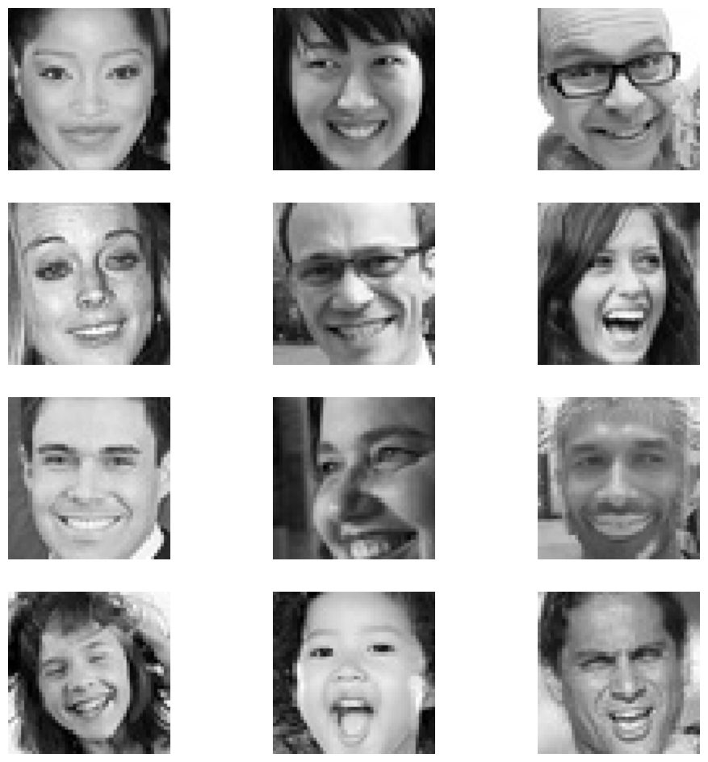

```python
# create a for loop to draw random samples from the dataset to visualize
happy_faces = [fn for fn in os.listdir(f'{DATADIR}/{CATEGORIES[0]}')]
select_happy = np.random.choice(happy_faces, 12, replace = False)

fig = plt.figure(figsize = (12, 12))

for i in range(12):
  ax = fig.add_subplot(4, 3, i + 1)
  fp = f'{DATADIR}/{CATEGORIES[0]}/{select_happy[i]}'
  fn = load_img(fp, target_size = (100, 100))
  plt.imshow(fn)
  plt.axis('off')
plt.show()
```

**Observations and Insights:__**

- A few characteristics that would make good identifying traits for the emotion displayed in these photos are:
  - Teeth showing, mouth open, eyebrows raised, eyes a bit squinted.
  - Head tilted backward, lines along mouth, nose, and chin.
  - rounded cheekbones from upper lip raising exposing teeth, 'crow's feet' lines on outer sides of the eyes

### **Sad**

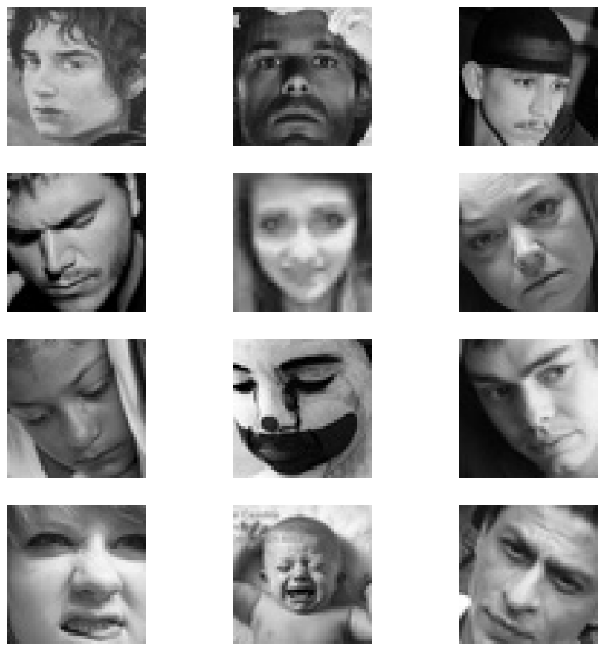

```python
# Duped the for loop that draws random samples from the dataset to visualize and adjusted to the correct data source
sad_faces = [fn for fn in os.listdir(f'{DATADIR}/{CATEGORIES[2]}')]
select_sad = np.random.choice(sad_faces, 12, replace = False)

fig = plt.figure(figsize = (12, 12))

for i in range(12):
  ax = fig.add_subplot(4, 3, i + 1)
  fp = f'{DATADIR}/{CATEGORIES[2]}/{select_sad[i]}'
  fn = load_img(fp, target_size = (150, 150))
  plt.imshow(fn)
  plt.axis('off')
plt.show()
```

**Observations and Insights:__**

- A few characteristics that would make good identifying traits for the emotion displayed in these photos are:
  - a furrowed brow causing lines and creases at the top of the nose between eyebrows and low on the forehead.
  - mouth closed or near closed with corners of the mouth curving downward.
  - head tilted down, eyes darkened compared to face
  - bottom lip pressed up against the upper lip causing tightening of the chin

### **Neutral**

[figure not shown]

```python
# Duped the for loop that draws random samples from the dataset to visualize and adjusted to the correct data source
neutral_faces = [fn for fn in os.listdir(f'{DATADIR}/{CATEGORIES[1]}')]
select_neutral = np.random.choice(neutral_faces, 12, replace = False)

fig = plt.figure(figsize = (12, 12))

for i in range(12):
  ax = fig.add_subplot(4, 3, i + 1)
  fp = f'{DATADIR}/{CATEGORIES[1]}/{select_neutral[i]}'
  fn = load_img(fp, target_size = (150, 150))
  plt.imshow(fn)
  plt.axis('off')
plt.show()
```

**Observations and Insights:__**

- A few characteristics that would make good identifying traits for the emotion displayed in these photos are:
  - lips together, fewer lines in faces, no tension in the skin from expression distortions
  - face is much more squared up to the frame, much less tilt or angles in the faces.
  - eyebrows straight across, not raised or furrowed, no tension

### **Surprised**

[figure not shown]

```python
# Duped the for loop that draws random samples from the dataset to visualize and adjusted to the correct data source
surprised_faces = [fn for fn in os.listdir(f'{DATADIR}/{CATEGORIES[3]}')]
select_surprised = np.random.choice(surprised_faces, 12, replace = False)

fig = plt.figure(figsize = (12, 12))

for i in range(12):
  ax = fig.add_subplot(4, 3, i + 1)
  fp = f'{DATADIR}/{CATEGORIES[3]}/{select_surprised[i]}'
  fn = load_img(fp, target_size = (150, 150))
  plt.imshow(fn)
  plt.axis('off')
plt.show()
```

**Observations and Insights:__**

- A few characteristics that would make good identifying traits for the emotion displayed in these photos are:
  - Open mouth but bottom teeth showing more than top, eyes opened wide with whites visible above pupil
  - eyebrows rased a lot, hands covering mouth,

## **Checking Distribution of Classes**

```python
# Count of the Classes
class_counts = y_train.Label.value_counts()
print('The total count for each class is: ')
print(class_counts)

print('-' * 50)

# Distribution of the Classes
class_dist = y_train.Label.value_counts(normalize = True)
print('The total distribution of each class is: ')
print(class_dist)
```

```
The total count for each class is:
sad         3982
neutral     3978
happy       3976
surprise    3173
Name: Label, dtype: int64
--------------------------------------------------
The total distribution of each class is:
sad         0.263552
neutral     0.263287
happy       0.263154
surprise    0.210007
Name: Label, dtype: float64
```

**Observations and Insights:__**

The distribution of the classes is almost perfectly equal. There are 5% less 'surprise' images in the dataset than the others.

This is an insignificant difference, outcomes shouldn't be affected.

**Think About It:**

- Are the classes equally distributed? If not, do you think the imbalance is too high? Will it be a problem as we progress?
  - The imbalance does not seem too high to cause an issue. The difference is small, 5%, and it only impacts 1 of the 4 classes.
- Are there any Exploratory Data Analysis tasks that we can do here? Would they provide any meaningful insights?
  - There are no more meaningful EDA left to perform that will draw out significant insights.

# **Facial Emotion Detection - Initial Model Building**

### **Creating our Data Loaders**

In this section, we are creating data loaders that we will use as inputs to our Neural Network.

**You have two options for the color_mode. You can set it to color_mode = 'rgb' or color_mode = 'grayscale'. You will need to try out both and see for yourself which one gives better performance.**

```python
# grayscale data loader
bw_datagen_train  = ImageDataGenerator()
bw_datagen_val = ImageDataGenerator()
bw_datagen_test = ImageDataGenerator()

bw_train_set = bw_datagen_train.flow_from_directory(folder_path + 'train/',
                                              target_size = (IMG_SIZE, IMG_SIZE),
                                              color_mode = "grayscale",
                                              batch_size = 32,
                                              class_mode = 'categorical',
                                              classes = ['happy', 'neutral', 'sad', 'surprise'],
                                              shuffle = True)

bw_validation_set = bw_datagen_val.flow_from_directory(folder_path + 'validation/',
                                              target_size = (IMG_SIZE, IMG_SIZE),
                                              color_mode = "grayscale",
                                              batch_size = 32,
                                              class_mode = 'categorical',
                                              classes = ['happy', 'neutral', 'sad', 'surprise'],
                                              shuffle = True)

bw_test_set = bw_datagen_test.flow_from_directory(folder_path + 'test/',
                                              target_size = (IMG_SIZE, IMG_SIZE),
                                              color_mode = "grayscale",
                                              batch_size = 32,
                                              class_mode = 'categorical',
                                              classes = ['happy', 'neutral', 'sad', 'surprise'],
                                              shuffle = True)
```

```
Found 15109 images belonging to 4 classes.
Found 4977 images belonging to 4 classes.
Found 128 images belonging to 4 classes.
```

```python
# rgb data loader

rgb_datagen_train  = ImageDataGenerator()
rgb_datagen_val = ImageDataGenerator()
rgb_datagen_test = ImageDataGenerator()

rgb_train_set = rgb_datagen_train.flow_from_directory(folder_path + 'train/',
                                              target_size = (IMG_SIZE, IMG_SIZE),
                                              color_mode = "rgb",
                                              batch_size = 32,
                                              class_mode = 'categorical',
                                              classes = ['happy', 'neutral', 'sad', 'surprise'],
                                              shuffle = True)

rgb_validation_set = rgb_datagen_val.flow_from_directory(folder_path + 'validation/',
                                              target_size = (IMG_SIZE, IMG_SIZE),
                                              color_mode = "rgb",
                                              batch_size = 32,
                                              class_mode = 'categorical',
                                              classes = ['happy', 'neutral', 'sad', 'surprise'],
                                              shuffle = True)

rgb_test_set = rgb_datagen_test.flow_from_directory(folder_path + 'test/',
                                              target_size = (IMG_SIZE, IMG_SIZE),
                                              color_mode = "rgb",
                                              batch_size = 32,
                                              class_mode = 'categorical',
                                              classes = ['happy', 'neutral', 'sad', 'surprise'],
                                              shuffle = True)
```

```
Found 15109 images belonging to 4 classes.
Found 4977 images belonging to 4 classes.
Found 128 images belonging to 4 classes.
```

**Think About It:**

- Are Convolutional Neural Networks the right approach? Should we have gone with Artificial Neural Networks instead?
  - A: Yes, Convolutional Neural Networks are the correct approach because they are particularly suited to analyze images. An Articial Neural Network could work but its unlikely to perform better than the CNN.
- What are the advantages of CNNs over ANNs and are they applicable here?
  - A: The largest advantage of CNN over ANN for this task is the CNN's utilization of convolution and pooling layers. The convolutional and pooling layers analyze, interpret, and extract features by 'passing' a smaller matrix 'over' the image's large pixel matrix. The smaller matrix acts as a filter as it progresses through the entire image's matrix reducing the data down to important features which then make up the next layer's 'image' to then be analyzed again and reduced further.

```python
# set up the random seeds for reproducability

backend.clear_session()

np.random.seed(1)
import random
random.seed(1)
tf.random.set_seed(1)
```

### **Creating the Base Neural Network**

```python
model_01 = Sequential()

model_01.add(Conv2D(filters = 64, kernel_size = (3, 3), padding = "same", input_shape = (IMG_SIZE, IMG_SIZE, 1)))

model_01.add(LeakyReLU(0.1))

model_01.add(Conv2D(filters = 32, kernel_size = (3, 3), padding = 'same'))

model_01.add(LeakyReLU(0.1))

model_01.add(MaxPooling2D(pool_size = (2, 2)))

model_01.add(Flatten())

model_01.add(Dense(30))

model_01.add(LeakyReLU(0.1))

model_01.add(Dense(4, activation = 'softmax'))

opt = Adam(learning_rate = 0.0001)
```

### **Compiling and Training the Model**

```python
model_01.compile(optimizer = opt, loss = 'categorical_crossentropy', metrics = ['accuracy'])

model_01.summary()
```

```
Model: "sequential"
_________________________________________________________________
 Layer (type)                Output Shape              Param #
=================================================================
 conv2d (Conv2D)             (None, 48, 48, 64)        640

 leaky_re_lu (LeakyReLU)     (None, 48, 48, 64)        0

 conv2d_1 (Conv2D)           (None, 48, 48, 32)        18464

 leaky_re_lu_1 (LeakyReLU)   (None, 48, 48, 32)        0

 max_pooling2d (MaxPooling2  (None, 24, 24, 32)        0
 D)

 flatten (Flatten)           (None, 18432)             0

 dense (Dense)               (None, 30)                552990

 leaky_re_lu_2 (LeakyReLU)   (None, 30)                0

 dense_1 (Dense)             (None, 4)                 124

=================================================================
Total params: 572218 (2.18 MB)
Trainable params: 572218 (2.18 MB)
Non-trainable params: 0 (0.00 Byte)
_________________________________________________________________
```

```python
es = EarlyStopping(monitor = 'val_loss', mode = 'min', verbose = 1, patience = 5)
mc = ModelCheckpoint('best_model_01.h5', monitor = 'val_accuracy', mode = 'max', verbose = 1, save_best_only = True)

first_model = model_01.fit(bw_train_set, epochs = 20, validation_data = bw_validation_set, callbacks = [es, mc])
```

```
Epoch 1: val_accuracy improved from -inf to 0.51678, saving model to best_model_01.h5
```

```
Epoch 2: val_accuracy improved from 0.51678 to 0.56399, saving model to best_model_01.h5
Epoch 3: val_accuracy improved from 0.56399 to 0.59172, saving model to best_model_01.h5
Epoch 4: val_accuracy improved from 0.59172 to 0.59192, saving model to best_model_01.h5
Epoch 5: val_accuracy did not improve from 0.59192
Epoch 6: val_accuracy improved from 0.59192 to 0.61945, saving model to best_model_01.h5
Epoch 7: val_accuracy did not improve from 0.61945
Epoch 8: val_accuracy did not improve from 0.61945
Epoch 9: val_accuracy did not improve from 0.61945
Epoch 10: val_accuracy did not improve from 0.61945
Epoch 11: val_accuracy did not improve from 0.61945
Epoch 11: early stopping
```

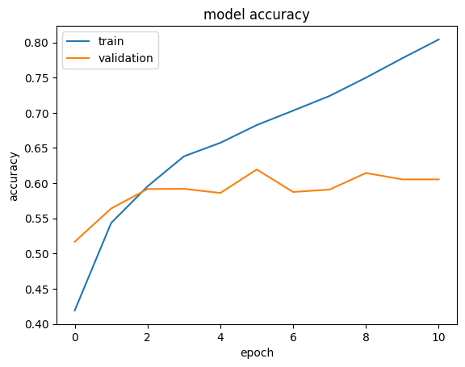

```python
plt.plot(first_model.history['accuracy'])
plt.plot(first_model.history['val_accuracy'])
plt.title('model accuracy')
plt.ylabel('accuracy')
plt.xlabel('epoch')
plt.legend(['train', 'validation'], loc = 'upper left')
plt.show()
```

### **Evaluating the Model on the Test Set**

```python
model_01.evaluate(bw_test_set)
```

```
[0.9858424663543701, 0.65625]
```

**Observations and Insights:__**

```python
# set up the random seeds for reproducability

backend.clear_session()

np.random.seed(1)
import random
random.seed(1)
tf.random.set_seed(1)
```

### **Creating the second Convolutional Neural Network**

- Try out a slightly larger architecture. Added layers and adjusted values. Will run this one with the bw color_mode dataset, and then right after do a run on the rgb color set for comparison.
- Changes: Activation function changed from designated LeakyReLU layers to a 'relu' function inside some of the Conv2D layers. Changed the learning rate value.

```python
model_02 = Sequential()

model_02.add(Conv2D(filters = 256, kernel_size = (3, 3), activation = 'relu', padding = "same", input_shape = (IMG_SIZE, IMG_SIZE, 1)))

model_02.add(Conv2D(filters = 256, kernel_size = (3, 3), activation = 'relu', padding = 'same'))

model_02.add(MaxPooling2D(pool_size = (2, 2)))

model_02.add(LeakyReLU(0.1))

model_02.add(Dropout(0.25))

model_02.add(Conv2D(filters = 128, kernel_size = (3, 3), activation = 'relu', padding = 'same'))

model_02.add(MaxPooling2D(pool_size = (2, 2)))

model_02.add(Flatten())

model_02.add(Dense(50))

model_02.add(LeakyReLU(0.1))

model_02.add(Dense(25))

model_02.add(LeakyReLU(0.1))

model_02.add(Dense(4, activation = 'softmax'))

opt = Adam(learning_rate = 0.0005)
```

### **Compiling and Training the Model**

```python
model_02.compile(optimizer = opt, loss = 'categorical_crossentropy', metrics = ['accuracy'])

model_02.summary()
```

```
Model: "sequential"
_________________________________________________________________
 Layer (type)                Output Shape              Param #
=================================================================
 conv2d (Conv2D)             (None, 48, 48, 256)       2560

 conv2d_1 (Conv2D)           (None, 48, 48, 256)       590080

 max_pooling2d (MaxPooling2  (None, 24, 24, 256)       0
 D)

 leaky_re_lu (LeakyReLU)     (None, 24, 24, 256)       0

 dropout (Dropout)           (None, 24, 24, 256)       0

 conv2d_2 (Conv2D)           (None, 24, 24, 128)       295040

 max_pooling2d_1 (MaxPoolin  (None, 12, 12, 128)       0
 g2D)

 flatten (Flatten)           (None, 18432)             0

 dense (Dense)               (None, 50)                921650

 leaky_re_lu_1 (LeakyReLU)   (None, 50)                0

 dense_1 (Dense)             (None, 25)                1275

 leaky_re_lu_2 (LeakyReLU)   (None, 25)                0

 dense_2 (Dense)             (None, 4)                 104

=================================================================
Total params: 1810709 (6.91 MB)
Trainable params: 1810709 (6.91 MB)
Non-trainable params: 0 (0.00 Byte)
_________________________________________________________________
```

```python
es = EarlyStopping(monitor = 'val_loss', mode = 'min', verbose = 1, patience = 5)
mc = ModelCheckpoint('best_model_02.h5', monitor = 'val_accuracy', mode = 'max', verbose = 1, save_best_only = True)

second_model = model_02.fit(bw_train_set, epochs = 20, validation_data = bw_validation_set, callbacks = [es, mc])
```

```
Epoch 1: val_accuracy improved from -inf to 0.43440, saving model to best_model_02.h5
Epoch 2: val_accuracy improved from 0.43440 to 0.55375, saving model to best_model_02.h5
Epoch 3: val_accuracy improved from 0.55375 to 0.61282, saving model to best_model_02.h5
Epoch 4: val_accuracy improved from 0.61282 to 0.62749, saving model to best_model_02.h5
Epoch 5: val_accuracy improved from 0.62749 to 0.65341, saving model to best_model_02.h5
Epoch 6: val_accuracy improved from 0.65341 to 0.67069, saving model to best_model_02.h5
Epoch 7: val_accuracy did not improve from 0.67069
Epoch 8: val_accuracy did not improve from 0.67069
Epoch 9: val_accuracy did not improve from 0.67069
Epoch 10: val_accuracy did not improve from 0.67069
Epoch 11: val_accuracy did not improve from 0.67069
Epoch 11: early stopping
```

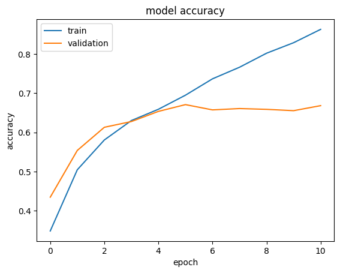

```python
plt.plot(second_model.history['accuracy'])
plt.plot(second_model.history['val_accuracy'])
plt.title('model accuracy')
plt.ylabel('accuracy')
plt.xlabel('epoch')
plt.legend(['train', 'validation'], loc = 'upper left')
plt.show()
```

### **Evaluating the Model on the Test Set**

```python
model_02.evaluate(bw_test_set)
```

```
[1.0287644863128662, 0.703125]
```

**Observations and Insights:__**

### Repeating model_02, this time with color mode RGB

```python
# set up the random seeds for reproducability

backend.clear_session()

np.random.seed(1)
import random
random.seed(1)
tf.random.set_seed(1)
```

```python
# identical structure to model_02

model_02a = Sequential()

model_02a.add(Conv2D(filters = 256, kernel_size = (3, 3), activation = 'relu', padding = "same", input_shape = (IMG_SIZE, IMG_SIZE, 3)))

model_02a.add(Conv2D(filters = 256, kernel_size = (3, 3), activation = 'relu', padding = 'same'))

model_02a.add(MaxPooling2D(pool_size = (2, 2)))

model_02a.add(LeakyReLU(0.1))

model_02a.add(Dropout(0.25))

model_02a.add(Conv2D(filters = 128, kernel_size = (3, 3), activation = 'relu', padding = 'same'))

model_02a.add(MaxPooling2D(pool_size = (2, 2)))

model_02a.add(Flatten())

model_02a.add(Dense(50))

model_02a.add(LeakyReLU(0.1))

model_02a.add(Dense(25))

model_02a.add(LeakyReLU(0.1))

model_02a.add(Dense(4, activation = 'softmax'))

opt = Adam(learning_rate = 0.0005)
```

```python
model_02a.compile(optimizer = opt, loss = 'categorical_crossentropy', metrics = ['accuracy'])

model_02a.summary()
```

```
Model: "sequential"
_________________________________________________________________
 Layer (type)                Output Shape              Param #
=================================================================
 conv2d (Conv2D)             (None, 48, 48, 256)       7168

 conv2d_1 (Conv2D)           (None, 48, 48, 256)       590080

 max_pooling2d (MaxPooling2  (None, 24, 24, 256)       0
 D)

 leaky_re_lu (LeakyReLU)     (None, 24, 24, 256)       0

 dropout (Dropout)           (None, 24, 24, 256)       0

 conv2d_2 (Conv2D)           (None, 24, 24, 128)       295040

 max_pooling2d_1 (MaxPoolin  (None, 12, 12, 128)       0
 g2D)

 flatten (Flatten)           (None, 18432)             0

 dense (Dense)               (None, 50)                921650

 leaky_re_lu_1 (LeakyReLU)   (None, 50)                0

 dense_1 (Dense)             (None, 25)                1275

 leaky_re_lu_2 (LeakyReLU)   (None, 25)                0

 dense_2 (Dense)             (None, 4)                 104

=================================================================
Total params: 1815317 (6.92 MB)
Trainable params: 1815317 (6.92 MB)
Non-trainable params: 0 (0.00 Byte)
_________________________________________________________________
```

```python
es = EarlyStopping(monitor = 'val_loss', mode = 'min', verbose = 1, patience = 5)
mc = ModelCheckpoint('best_model_02a.h5', monitor = 'val_accuracy', mode = 'max', verbose = 1, save_best_only = True)

second_a_model = model_02a.fit(rgb_train_set, epochs = 20, validation_data = rgb_validation_set, callbacks = [es, mc])
```

```
Epoch 1: val_accuracy improved from -inf to 0.43460, saving model to best_model_02a.h5
Epoch 2: val_accuracy improved from 0.43460 to 0.52723, saving model to best_model_02a.h5
Epoch 3: val_accuracy improved from 0.52723 to 0.55957, saving model to best_model_02a.h5
Epoch 4: val_accuracy improved from 0.55957 to 0.60277, saving model to best_model_02a.h5
Epoch 5: val_accuracy improved from 0.60277 to 0.62025, saving model to best_model_02a.h5
Epoch 6: val_accuracy improved from 0.62025 to 0.64256, saving model to best_model_02a.h5
Epoch 7: val_accuracy did not improve from 0.64256
Epoch 8: val_accuracy did not improve from 0.64256
Epoch 9: val_accuracy did not improve from 0.64256
Epoch 10: val_accuracy did not improve from 0.64256
Epoch 11: val_accuracy did not improve from 0.64256
Epoch 11: early stopping
```

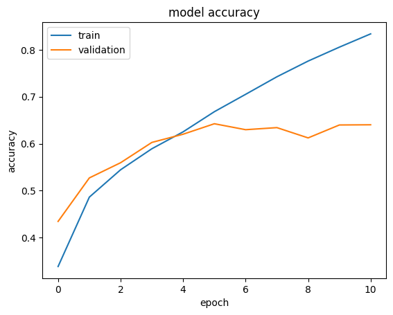

```python
plt.plot(second_a_model.history['accuracy'])
plt.plot(second_a_model.history['val_accuracy'])
plt.title('model accuracy')
plt.ylabel('accuracy')
plt.xlabel('epoch')
plt.legend(['train', 'validation'], loc = 'upper left')
plt.show()
```

```python
model_02a.evaluate(rgb_test_set)
```

```
[0.9269284009933472, 0.6640625]
```

**Observations and Insights:__**

## **Think About It:**

- Did the models have a satisfactory performance? If not, then what are the possible reasons?
- Which Color mode showed better overall performance? What are the possible reasons? Do you think having 'rgb' color mode is needed because the images are already black and white?

# **Facial Emotion Detection - Model Building with Transfer Learning Architectures**

In this section, we will create several Transfer Learning architectures. For the pre-trained models, we will select three popular architectures namely, VGG16, ResNet v2, and Efficient Net. The difference between these architectures and the previous architectures is that these will require 3 input channels while the earlier ones worked on 'grayscale' images. Therefore, we need to create new DataLoaders.

### **Creating our Data Loaders for Transfer Learning Architectures**

In this section, we are creating data loaders that we will use as inputs to our Neural Network. We will have to go with color_mode = 'rgb' as this is the required format for the transfer learning architectures.

```python
# set up the random seeds for reproducability
backend.clear_session()

np.random.seed(1)
import random
random.seed(1)
tf.random.set_seed(1)
```

```python
# rgb data loader

vgg_datagen_train  = ImageDataGenerator()
vgg_datagen_val = ImageDataGenerator()
vgg_datagen_test = ImageDataGenerator()

vgg_train_set = vgg_datagen_train.flow_from_directory(folder_path + 'train/',
                                              target_size = (IMG_SIZE, IMG_SIZE),
                                              color_mode = "rgb",
                                              batch_size = 32,
                                              class_mode = 'categorical',
                                              classes = ['happy', 'neutral', 'sad', 'surprise'],
                                              shuffle = True)

vgg_validation_set = vgg_datagen_val.flow_from_directory(folder_path + 'validation/',
                                              target_size = (IMG_SIZE, IMG_SIZE),
                                              color_mode = "rgb",
                                              batch_size = 32,
                                              class_mode = 'categorical',
                                              classes = ['happy', 'neutral', 'sad', 'surprise'],
                                              shuffle = True)

vgg_test_set = vgg_datagen_test.flow_from_directory(folder_path + 'test/',
                                              target_size = (IMG_SIZE, IMG_SIZE),
                                              color_mode = "rgb",
                                              batch_size = 32,
                                              class_mode = 'categorical',
                                              classes = ['happy', 'neutral', 'sad', 'surprise'],
                                              shuffle = True)
```

```
Found 15109 images belonging to 4 classes.
Found 4977 images belonging to 4 classes.
Found 128 images belonging to 4 classes.
```

## **VGG16 Model**

### **Importing the VGG16 Architecture**

```python
# import libraries for vgg16

from tensorflow.keras import Model
from tensorflow.keras.applications.vgg16 import VGG16
```

### **Model Building**

- Import VGG16 upto the layer of your choice and add Fully Connected layers on top of it.

```python
vgg_model_01 = VGG16(weights = 'imagenet',
                     include_top = False,
                     input_shape = (IMG_SIZE, IMG_SIZE, 3), pooling = 'max')
```

```
Downloading data from https://storage.googleapis.com/tensorflow/keras-applications/vgg16/vgg16_weights_tf_dim_ordering_tf_kernels_notop.h5
```

```python
vgg_model_01.summary()
```

```
Model: "vgg16"
_________________________________________________________________
 Layer (type)                Output Shape              Param #
=================================================================
 input_1 (InputLayer)        [(None, 48, 48, 3)]       0

 block1_conv1 (Conv2D)       (None, 48, 48, 64)        1792

 block1_conv2 (Conv2D)       (None, 48, 48, 64)        36928

 block1_pool (MaxPooling2D)  (None, 24, 24, 64)        0

 block2_conv1 (Conv2D)       (None, 24, 24, 128)       73856

 block2_conv2 (Conv2D)       (None, 24, 24, 128)       147584

 block2_pool (MaxPooling2D)  (None, 12, 12, 128)       0

 block3_conv1 (Conv2D)       (None, 12, 12, 256)       295168

 block3_conv2 (Conv2D)       (None, 12, 12, 256)       590080

 block3_conv3 (Conv2D)       (None, 12, 12, 256)       590080

 block3_pool (MaxPooling2D)  (None, 6, 6, 256)         0

 block4_conv1 (Conv2D)       (None, 6, 6, 512)         1180160

 block4_conv2 (Conv2D)       (None, 6, 6, 512)         2359808

 block4_conv3 (Conv2D)       (None, 6, 6, 512)         2359808

 block4_pool (MaxPooling2D)  (None, 3, 3, 512)         0

 block5_conv1 (Conv2D)       (None, 3, 3, 512)         2359808

 block5_conv2 (Conv2D)       (None, 3, 3, 512)         2359808

 block5_conv3 (Conv2D)       (None, 3, 3, 512)         2359808

 block5_pool (MaxPooling2D)  (None, 1, 1, 512)         0

 global_max_pooling2d (Glob  (None, 512)               0
 alMaxPooling2D)

=================================================================
Total params: 14714688 (56.13 MB)
Trainable params: 14714688 (56.13 MB)
Non-trainable params: 0 (0.00 Byte)
_________________________________________________________________
```

```python
transfer_layer = vgg_model_01.get_layer('block4_pool')
vgg_model_01.trainable = False
```

### **Compiling and Training the VGG16 Model**

```python
x = Flatten()(transfer_layer.output)

x = Dense(256, activation = 'relu')(x)

x = Dense(256, activation = 'relu')(x)

x = Dense(256, activation = 'relu')(x)

x = BatchNormalization()(x)

x = Dropout(0.2)(x)

x = Dense(256, activation = 'relu')(x)

x = Dense(256, activation = 'relu')(x)

x = Dense(256, activation = 'relu')(x)

x = Dense(256, activation = 'relu')(x)

x = BatchNormalization()(x)

x = Dropout(0.2)(x)

x = Dense(256, activation = 'relu')(x)

prediction = Dense(4, activation = 'softmax')(x)

first_vgg_model = Model(vgg_model_01.input, prediction)
```

```python
first_vgg_model.compile(loss = 'categorical_crossentropy', optimizer = Adam(learning_rate = 0.0001), metrics = ['accuracy'])
```

```python
es = EarlyStopping(monitor = 'val_loss', mode = 'min', verbose = 1, patience = 6)
mc = ModelCheckpoint('best_vgg_01_rgb.h5', monitor = 'val_accuracy', mode = 'max', verbose = 1, save_best_only = True)

vgg_01 = first_vgg_model.fit(vgg_train_set, epochs = 30, validation_data = vgg_validation_set, verbose = 1, callbacks = [es, mc])
```

```
Epoch 1: val_accuracy improved from -inf to 0.54229, saving model to best_vgg_01_rgb.h5
```

```
Epoch 2: val_accuracy improved from 0.54229 to 0.62266, saving model to best_vgg_01_rgb.h5
Epoch 3: val_accuracy did not improve from 0.62266
Epoch 4: val_accuracy improved from 0.62266 to 0.65763, saving model to best_vgg_01_rgb.h5
Epoch 5: val_accuracy improved from 0.65763 to 0.67249, saving model to best_vgg_01_rgb.h5
Epoch 6: val_accuracy did not improve from 0.67249
Epoch 7: val_accuracy improved from 0.67249 to 0.68093, saving model to best_vgg_01_rgb.h5
Epoch 8: val_accuracy improved from 0.68093 to 0.69078, saving model to best_vgg_01_rgb.h5
Epoch 9: val_accuracy did not improve from 0.69078
Epoch 10: val_accuracy did not improve from 0.69078
Epoch 11: val_accuracy improved from 0.69078 to 0.69640, saving model to best_vgg_01_rgb.h5
Epoch 12: val_accuracy did not improve from 0.69640
Epoch 13: val_accuracy did not improve from 0.69640
Epoch 13: early stopping
```

### **Evaluating the VGG16 model**

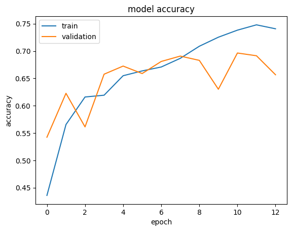

```python
plt.plot(vgg_01.history['accuracy'])
plt.plot(vgg_01.history['val_accuracy'])
plt.title('model accuracy')
plt.ylabel('accuracy')
plt.xlabel('epoch')
plt.legend(['train', 'validation'], loc = 'upper left')
plt.show()
```

```python
first_vgg_model.evaluate(vgg_test_set)
```

```
[0.8384191989898682, 0.671875]
```

**Think About It:**

**Observations and Insights:__**

**Note: You can even go back and build your own architecture on top of the VGG16 Transfer layer and see if you can improve the performance**

## **ResNet V2 Model**

```python
from keras import layers
```

### **Model Building**

- Import Resnet v2 upto the layer of your choice and add Fully Connected layers on top of it.

```python
x_train_use = keras.applications.resnet_v2.preprocess_input(X_train)
x_test_use = keras.applications.resnet_v2.preprocess_input(X_test)
x_val_use = keras.applications.resnet_v2.preprocess_input(X_val)

base_model = keras.applications.ResNet50V2(
    include_top = False,
    weights="imagenet",
    input_tensor=None,
    input_shape = (IMG_SIZE, IMG_SIZE, 3),
    pooling = 'max',
    classes=4,
    classifier_activation="softmax")

base_model.trainable = False

inputs = keras.Input(shape=(IMG_SIZE, IMG_SIZE, 3))
x = base_model(inputs, training = False)
x = keras.layers.Dense(128, activation = 'relu')(x)
x = keras.layers.Dropout(0.2)(x)
x = keras.layers.Dense(64, activation = 'relu')(x)
x = keras.layers.BatchNormalization()(x)
x = keras.layers.Dense(64, activation = 'relu')(x)
x = Flatten()(x)
x = keras.layers.Dense(64, activation = 'relu')(x)
x = keras.layers.Dense(64, activation = 'relu')(x)
x = keras.layers.Dense(64, activation = 'relu')(x)


outputs = keras.layers.Dense(4, activation = 'softmax')(x)
model = keras.Model(inputs, outputs)
```

```python
model.summary()
```

[output not shown]

### **Compiling and Training the Model**

```python
es = EarlyStopping(monitor = 'val_loss', mode = 'min', verbose = 1, patience = 8)
mc = ModelCheckpoint('best_rnv2.h5', monitor = 'val_accuracy', mode = 'max', verbose = 1, save_best_only = True)

model.compile(optimizer = Adam(learning_rate = 0.00001), loss = 'categorical_crossentropy', metrics = ['accuracy'])

rn_model = model.fit(x_train_use, y_train_encoded, epochs = 30, callbacks = [mc, es], validation_split = 0.1)
```

```
Epoch 1: val_accuracy improved from -inf to 0.29252, saving model to best_rnv2.h5
```

```
Epoch 2: val_accuracy improved from 0.29252 to 0.29318, saving model to best_rnv2.h5
Epoch 3: val_accuracy improved from 0.29318 to 0.35010, saving model to best_rnv2.h5
Epoch 4: val_accuracy improved from 0.35010 to 0.40371, saving model to best_rnv2.h5
Epoch 5: val_accuracy improved from 0.40371 to 0.45731, saving model to best_rnv2.h5
Epoch 6: val_accuracy improved from 0.45731 to 0.48312, saving model to best_rnv2.h5
Epoch 7: val_accuracy improved from 0.48312 to 0.49835, saving model to best_rnv2.h5
Epoch 8: val_accuracy improved from 0.49835 to 0.51158, saving model to best_rnv2.h5
Epoch 9: val_accuracy improved from 0.51158 to 0.53408, saving model to best_rnv2.h5
Epoch 10: val_accuracy improved from 0.53408 to 0.54004, saving model to best_rnv2.h5
Epoch 11: val_accuracy improved from 0.54004 to 0.54600, saving model to best_rnv2.h5
Epoch 12: val_accuracy improved from 0.54600 to 0.55659, saving model to best_rnv2.h5
Epoch 13: val_accuracy improved from 0.55659 to 0.56916, saving model to best_rnv2.h5
Epoch 14: val_accuracy improved from 0.56916 to 0.57512, saving model to best_rnv2.h5
Epoch 15: val_accuracy did not improve from 0.57512
Epoch 16: val_accuracy improved from 0.57512 to 0.58173, saving model to best_rnv2.h5
Epoch 17: val_accuracy did not improve from 0.58173
Epoch 18: val_accuracy improved from 0.58173 to 0.58372, saving model to best_rnv2.h5
Epoch 19: val_accuracy improved from 0.58372 to 0.58703, saving model to best_rnv2.h5
Epoch 20: val_accuracy improved from 0.58703 to 0.59365, saving model to best_rnv2.h5
Epoch 21: val_accuracy improved from 0.59365 to 0.59563, saving model to best_rnv2.h5
Epoch 22: val_accuracy improved from 0.59563 to 0.59629, saving model to best_rnv2.h5
Epoch 23: val_accuracy improved from 0.59629 to 0.60225, saving model to best_rnv2.h5
Epoch 24: val_accuracy improved from 0.60225 to 0.60291, saving model to best_rnv2.h5
Epoch 25: val_accuracy improved from 0.60291 to 0.60424, saving model to best_rnv2.h5
Epoch 26: val_accuracy improved from 0.60424 to 0.60490, saving model to best_rnv2.h5
Epoch 27: val_accuracy improved from 0.60490 to 0.61152, saving model to best_rnv2.h5
Epoch 28: val_accuracy did not improve from 0.61152
Epoch 29: val_accuracy improved from 0.61152 to 0.61416, saving model to best_rnv2.h5
Epoch 30: val_accuracy improved from 0.61416 to 0.61747, saving model to best_rnv2.h5
```

```python
# set up the random seeds for reproducability
backend.clear_session()

np.random.seed(1)
import random
random.seed(1)
tf.random.set_seed(1)
```

### **Evaluating the ResNet Model**

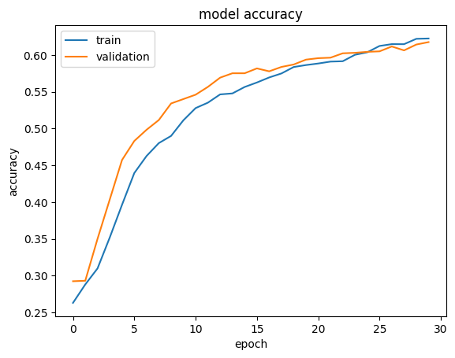

```python
plt.plot(rn_model.history['accuracy'])
plt.plot(rn_model.history['val_accuracy'])
plt.title('model accuracy')
plt.ylabel('accuracy')
plt.xlabel('epoch')
plt.legend(['train', 'validation'], loc = 'upper left')
plt.show()
```

```python
# reimport for evaluation after colab crash

imported_rn_model = h5py.File('/content/best_rnv2.h5', 'r')
new_rn_model = tf.keras.models.load_model(imported_rn_model)

new_rn_model.summary()
```

[output not shown]

```python
new_rn_model.evaluate(x_test_use, (y_test_encoded))
```

```
[0.8520301580429077, 0.6328125]
```

**Observations and Insights:__**

**Note: You can even go back and build your own architecture on top of the ResNet Transfer layer and see if you can improve the performance.**

## **EfficientNet Model**

This model caused a lot of colab crashes. I added a lot of the import and data loading back into this section as a way to help make crashes more efficient to manage.

### **Import Files and Unzip**

```python
# For Data Preprocessing
import pandas as pd
import numpy as np

# For Data Visualization
import matplotlib.pyplot as plt
import seaborn as sns
import cv2

# For working with a zip file
import zipfile
import os

# For Model Building
import tensorflow as tf
import keras
from tensorflow.keras.models import Sequential, Model
from tensorflow.keras.layers import Dense, Dropout, Flatten
from tensorflow.keras.layers import Conv2D, MaxPooling2D, BatchNormalization, Activation, Input, LeakyReLU, Activation
from tensorflow.keras import backend
from tensorflow.keras.utils import to_categorical
from tensorflow.keras.optimizers import RMSprop, Adam, SGD
from tensorflow.keras.callbacks import EarlyStopping
from tensorflow.keras.callbacks import ModelCheckpoint
from tensorflow.keras import losses, optimizers
from tensorflow.keras.preprocessing.image import load_img
from google.colab.patches import cv2_imshow

# the EfficientNet Model
from keras.applications import EfficientNetB0
from keras import layers
```

```python
# unzip images, for when reconnecting to GPU
path = '/content/disc/MyDrive/Ky/Applied Data Science/DataSets/Facial_emotion_images.zip'

# extract files from the .zip file
with zipfile.ZipFile(path, 'r') as zip_ref:
    zip_ref.extractall()
```

#### **Fetch and Prep the data for this model**

```python
#training data
DATADIR = '/content/Facial_emotion_images/train'
CATEGORIES = ['happy', 'neutral', 'sad', 'surprise']
ef_net_size = 224

#create training data
ef_training_data = []

def make_ef_training_data():
  for category in CATEGORIES:
    path = os.path.join(DATADIR, category)
    classifier_number = category

    for img in os.listdir(path):
      array01 = cv2.imread(os.path.join(path, img))
      array02 = cv2.resize(array01, (ef_net_size, ef_net_size))
      ef_training_data.append([array02, classifier_number])

make_ef_training_data()
```

```python
#test data
DATADIR_test = '/content/Facial_emotion_images/test'
CATEGORIES = ['happy', 'neutral', 'sad', 'surprise']
ef_net_size = 224

#create test data
ef_test_data = []

def make_ef_test_data():
  for category in CATEGORIES:
    path = os.path.join(DATADIR_test, category)
    classifier_number = category

    for img in os.listdir(path):
      array01_test = cv2.imread(os.path.join(path, img))
      array02_test = cv2.resize(array01_test, (ef_net_size, ef_net_size))
      ef_test_data.append([array02_test, classifier_number])

make_ef_test_data()
```

```python
#validation data
DATADIR_validation = '/content/Facial_emotion_images/validation'
CATEGORIES = ['happy', 'neutral', 'sad', 'surprise']
ef_net_size = 224

#create validation data
ef_validation_data = []

def make_ef_validation_data():
  for category in CATEGORIES:
    path = os.path.join(DATADIR_validation, category)
    classifier_number = category

    for img in os.listdir(path):
      array01_validation = cv2.imread(os.path.join(path, img))
      array02_validation = cv2.resize(array01_validation, (ef_net_size, ef_net_size))
      ef_validation_data.append([array02_validation, classifier_number])

make_ef_validation_data()
```

```python
ef_X_train = []
ef_y_train = []

np.random.shuffle(ef_training_data)
for features, label in ef_training_data:
  ef_X_train.append(features)
  ef_y_train.append(label)

ef_X_test = []
ef_y_test = []

np.random.shuffle(ef_test_data)
for features, label in ef_test_data:
  ef_X_test.append(features)
  ef_y_test.append(label)

ef_X_validation = []
ef_y_validation = []

np.random.shuffle(ef_validation_data)
for features, label in ef_validation_data:
  ef_X_validation.append(features)
  ef_y_validation.append(label)
```

```python
ef_X_train = np.array(ef_X_train)
ef_X_test = np.array(ef_X_test)
ef_X_validation = np.array(ef_X_validation)

print(ef_X_train.shape)

ef_y_train = pd.DataFrame(ef_y_train, columns = ['Label'], dtype = object)
ef_y_test = pd.DataFrame(ef_y_test, columns = ['Label'], dtype = object)
ef_y_validation = pd.DataFrame(ef_y_validation, columns = ['Label'], dtype = object)

print(ef_y_train.shape)
```

```
(15109, 224, 224, 3)
(15109, 1)
```

#### **encode target variable**

```python
# encode target variables for ef model
ef_y_train_encoded = []

for label_name in ef_y_train['Label']:
    if(label_name == 'sad'):
      ef_y_train_encoded.append(0)

    if(label_name == 'neutral'):
      ef_y_train_encoded.append(1)

    if(label_name == 'happy'):
      ef_y_train_encoded.append(2)

    if(label_name == 'surprise'):
      ef_y_train_encoded.append(3)

ef_y_train_encoded = to_categorical(ef_y_train_encoded, 4)
print(ef_y_train_encoded)

ef_y_test_encoded = []

for label_name in ef_y_test['Label']:
    if(label_name == 'sad'):
      ef_y_test_encoded.append(0)

    if(label_name == 'neutral'):
      ef_y_test_encoded.append(1)

    if(label_name == 'happy'):
      ef_y_test_encoded.append(2)

    if(label_name == 'surprise'):
      ef_y_test_encoded.append(3)

ef_y_test_encoded = to_categorical(ef_y_test_encoded, 4)
print(ef_y_test_encoded)

ef_y_validation_encoded = []

for label_name in ef_y_validation['Label']:
    if(label_name == 'sad'):
      ef_y_validation_encoded.append(0)

    if(label_name == 'neutral'):
      ef_y_validation_encoded.append(1)

    if(label_name == 'happy'):
      ef_y_validation_encoded.append(2)

    if(label_name == 'surprise'):
      ef_y_validation_encoded.append(3)

ef_y_validation_encoded = to_categorical(ef_y_validation_encoded, 4)
print(ef_y_validation_encoded)
```

[output not shown]

[output cut: 87 more lines]

```
 [0. 1. 0. 0.]
 [1. 0. 0. 0.]
 [0. 0. 0. 1.]
 [1. 0. 0. 0.]
 [0. 1. 0. 0.]
 [0. 0. 0. 1.]
 [0. 0. 0. 1.]
 [0. 0. 1. 0.]]
[[0. 0. 1. 0.]
 [1. 0. 0. 0.]
 [0. 0. 1. 0.]
 ...
 [1. 0. 0. 0.]
 [1. 0. 0. 0.]
 [0. 0. 1. 0.]]
```

### **Model Building**

- Import EfficientNet upto the layer of your choice and add Fully Connected layers on top of it.

```python
def build_ef_model(num_classes):
  inputs = layers.Input(shape = (224, 224, 3), tensor = None)
  model_ef = EfficientNetB0(include_top = False, input_tensor = inputs, input_shape = (224, 224, 3), weights = 'imagenet', classes = 4)

  model_ef.trainable = False

  x = layers.GlobalAveragePooling2D(name = 'avg_pool')(model_ef.output)
  x = layers.BatchNormalization()(x)
  x = layers.Dense(254, activation = 'relu')(x)
  x = layers.Dense(254, activation = 'relu')(x)
  x = layers.Dropout(0.2)(x)
  x = layers.Dense(254, activation = 'relu')(x)
  x = layers.Dense(254, activation = 'relu')(x)
  x = layers.Flatten()(x)
  x = layers.Dense(64, activation = 'relu')(x)
  x = layers.Dropout(0.2)(x)
  x = layers.Dense(64, activation = 'relu')(x)
  x = layers.Dense(64, activation = 'relu')(x)

  outputs = layers.Dense(num_classes, activation = 'softmax', name = 'pred')(x)

  ef_model = keras.Model(inputs, outputs, name = 'EfficientNet')
  optimizer = Adam(learning_rate = 0.0001)
  ef_model.compile(optimizer = optimizer, loss = 'categorical_crossentropy', metrics = ['accuracy'])

  return ef_model
```

### **Compiling and Training the Model**

```python
the_model = build_ef_model(4)
the_model.summary()
```

```
Downloading data from https://storage.googleapis.com/keras-applications/efficientnetb0_notop.h5
Model: "EfficientNet"
__________________________________________________________________________________________________
 Layer (type)                Output Shape                 Param #   Connected to
==================================================================================================
 input_1 (InputLayer)        [(None, 224, 224, 3)]        0         []

 rescaling (Rescaling)       (None, 224, 224, 3)          0         ['input_1[0][0]']

 normalization (Normalizati  (None, 224, 224, 3)          7         ['rescaling[0][0]']
 on)

 rescaling_1 (Rescaling)     (None, 224, 224, 3)          0         ['normalization[0][0]']

 stem_conv_pad (ZeroPadding  (None, 225, 225, 3)          0         ['rescaling_1[0][0]']
 2D)

 stem_conv (Conv2D)          (None, 112, 112, 32)         864       ['stem_conv_pad[0][0]']

 stem_bn (BatchNormalizatio  (None, 112, 112, 32)         128       ['stem_conv[0][0]']
 n)

 stem_activation (Activatio  (None, 112, 112, 32)         0         ['stem_bn[0][0]']
 n)

 block1a_dwconv (DepthwiseC  (None, 112, 112, 32)         288       ['stem_activation[0][0]']
 onv2D)

 block1a_bn (BatchNormaliza  (None, 112, 112, 32)         128       ['block1a_dwconv[0][0]']
 tion)

 block1a_activation (Activa  (None, 112, 112, 32)         0         ['block1a_bn[0][0]']
 tion)

 block1a_se_squeeze (Global  (None, 32)                   0         ['block1a_activation[0][0]']
 AveragePooling2D)

 block1a_se_reshape (Reshap  (None, 1, 1, 32)             0         ['block1a_se_squeeze[0][0]']
 e)

```

[output cut: 651 more lines]

```
 dense_4 (Dense)             (None, 64)                   16320     ['flatten[0][0]']

 dropout_1 (Dropout)         (None, 64)                   0         ['dense_4[0][0]']

 dense_5 (Dense)             (None, 64)                   4160      ['dropout_1[0][0]']

 dense_6 (Dense)             (None, 64)                   4160      ['dense_5[0][0]']

 pred (Dense)                (None, 4)                    260       ['dense_6[0][0]']

==================================================================================================
Total params: 4599275 (17.54 MB)
Trainable params: 547144 (2.09 MB)
Non-trainable params: 4052131 (15.46 MB)
__________________________________________________________________________________________________
```

```python
es = EarlyStopping(monitor = 'val_loss', mode = 'min', verbose = 1, patience = 4)
mc = ModelCheckpoint('best_efnet.h5', monitor = 'val_accuracy', mode = 'max', verbose = 1, save_best_only = True)

epochs = 40
ef_net_model_01 = the_model.fit(ef_X_train, ef_y_train_encoded, epochs = epochs, callbacks = [mc, es], batch_size = 32, validation_split = 0.1)
```

```
Epoch 1: val_accuracy improved from -inf to 0.60754, saving model to best_efnet.h5
```

```
Epoch 2: val_accuracy improved from 0.60754 to 0.65718, saving model to best_efnet.h5
Epoch 3: val_accuracy improved from 0.65718 to 0.66843, saving model to best_efnet.h5
Epoch 4: val_accuracy improved from 0.66843 to 0.68696, saving model to best_efnet.h5
Epoch 5: val_accuracy improved from 0.68696 to 0.71013, saving model to best_efnet.h5
Epoch 6: val_accuracy did not improve from 0.71013
Epoch 7: val_accuracy improved from 0.71013 to 0.71343, saving model to best_efnet.h5
Epoch 8: val_accuracy did not improve from 0.71343
Epoch 9: val_accuracy improved from 0.71343 to 0.71741, saving model to best_efnet.h5
Epoch 10: val_accuracy improved from 0.71741 to 0.72204, saving model to best_efnet.h5
Epoch 11: val_accuracy did not improve from 0.72204
Epoch 11: early stopping
```

### **Evaluating the EfficientnetNet Model**

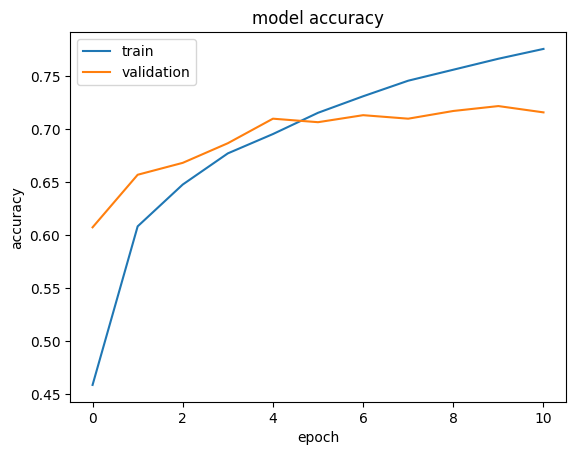

```python
def plot_hist(hist):
    plt.plot(ef_net_model_01.history["accuracy"])
    plt.plot(ef_net_model_01.history["val_accuracy"])
    plt.title("model accuracy")
    plt.ylabel("accuracy")
    plt.xlabel("epoch")
    plt.legend(["train", "validation"], loc="upper left")
    plt.show()


plot_hist(ef_net_model_01)
```

```python
the_model.evaluate(ef_X_test, (ef_y_test_encoded))
```

```
[0.687409520149231, 0.7265625]
```

**Observations & Insights:__**

#### **Unfreeze the model and fine-tune training further**

- The model performed very well with all of the transfer layers untrainable. This next section is where some of the transfer layers will be allowed to train in an attempt to fine tune the well-performing model.

```python
# reimport for evaluation after colab crash

imported_efnet_model = h5py.File('/content/best_efnet.h5', 'r')
new_efnet_model = tf.keras.models.load_model(imported_efnet_model)

new_efnet_model.summary()
```

```
Model: "EfficientNet"
__________________________________________________________________________________________________
 Layer (type)                Output Shape                 Param #   Connected to
==================================================================================================
 input_1 (InputLayer)        [(None, 224, 224, 3)]        0         []

 rescaling (Rescaling)       (None, 224, 224, 3)          0         ['input_1[0][0]']

 normalization (Normalizati  (None, 224, 224, 3)          7         ['rescaling[0][0]']
 on)

 rescaling_1 (Rescaling)     (None, 224, 224, 3)          0         ['normalization[0][0]']

 stem_conv_pad (ZeroPadding  (None, 225, 225, 3)          0         ['rescaling_1[0][0]']
 2D)

 stem_conv (Conv2D)          (None, 112, 112, 32)         864       ['stem_conv_pad[0][0]']

 stem_bn (BatchNormalizatio  (None, 112, 112, 32)         128       ['stem_conv[0][0]']
 n)

 stem_activation (Activatio  (None, 112, 112, 32)         0         ['stem_bn[0][0]']
 n)

 block1a_dwconv (DepthwiseC  (None, 112, 112, 32)         288       ['stem_activation[0][0]']
 onv2D)

 block1a_bn (BatchNormaliza  (None, 112, 112, 32)         128       ['block1a_dwconv[0][0]']
 tion)

 block1a_activation (Activa  (None, 112, 112, 32)         0         ['block1a_bn[0][0]']
 tion)

 block1a_se_squeeze (Global  (None, 32)                   0         ['block1a_activation[0][0]']
 AveragePooling2D)

 block1a_se_reshape (Reshap  (None, 1, 1, 32)             0         ['block1a_se_squeeze[0][0]']
 e)

 block1a_se_reduce (Conv2D)  (None, 1, 1, 8)              264       ['block1a_se_reshape[0][0]']
```

[output cut: 650 more lines]

```
 dense_4 (Dense)             (None, 64)                   16320     ['flatten[0][0]']

 dropout_1 (Dropout)         (None, 64)                   0         ['dense_4[0][0]']

 dense_5 (Dense)             (None, 64)                   4160      ['dropout_1[0][0]']

 dense_6 (Dense)             (None, 64)                   4160      ['dense_5[0][0]']

 pred (Dense)                (None, 4)                    260       ['dense_6[0][0]']

==================================================================================================
Total params: 4599275 (17.54 MB)
Trainable params: 547144 (2.09 MB)
Non-trainable params: 4052131 (15.46 MB)
__________________________________________________________________________________________________
```

```python
# unfreeze the model for fine tuning

def unfreeze_model(model):
  for layer in model.layers[-40:]:
    if not isinstance(layer, layers.BatchNormalization):
      layer.trainable = True
  optimizer = Adam(learning_rate = 0.000001)
  model.compile(
      optimizer = optimizer, loss = 'categorical_crossentropy', metrics = ['accuracy']
  )

unfreeze_model(new_efnet_model)
```

```python
new_efnet_model.summary()
```

```
Model: "EfficientNet"
__________________________________________________________________________________________________
 Layer (type)                Output Shape                 Param #   Connected to
==================================================================================================
 input_1 (InputLayer)        [(None, 224, 224, 3)]        0         []

 rescaling (Rescaling)       (None, 224, 224, 3)          0         ['input_1[0][0]']

 normalization (Normalizati  (None, 224, 224, 3)          7         ['rescaling[0][0]']
 on)

 rescaling_1 (Rescaling)     (None, 224, 224, 3)          0         ['normalization[0][0]']

 stem_conv_pad (ZeroPadding  (None, 225, 225, 3)          0         ['rescaling_1[0][0]']
 2D)

 stem_conv (Conv2D)          (None, 112, 112, 32)         864       ['stem_conv_pad[0][0]']

 stem_bn (BatchNormalizatio  (None, 112, 112, 32)         128       ['stem_conv[0][0]']
 n)

 stem_activation (Activatio  (None, 112, 112, 32)         0         ['stem_bn[0][0]']
 n)

 block1a_dwconv (DepthwiseC  (None, 112, 112, 32)         288       ['stem_activation[0][0]']
 onv2D)

 block1a_bn (BatchNormaliza  (None, 112, 112, 32)         128       ['block1a_dwconv[0][0]']
 tion)

 block1a_activation (Activa  (None, 112, 112, 32)         0         ['block1a_bn[0][0]']
 tion)

 block1a_se_squeeze (Global  (None, 32)                   0         ['block1a_activation[0][0]']
 AveragePooling2D)

 block1a_se_reshape (Reshap  (None, 1, 1, 32)             0         ['block1a_se_squeeze[0][0]']
 e)

 block1a_se_reduce (Conv2D)  (None, 1, 1, 8)              264       ['block1a_se_reshape[0][0]']
```

[output cut: 650 more lines]

```
 dense_4 (Dense)             (None, 64)                   16320     ['flatten[0][0]']

 dropout_1 (Dropout)         (None, 64)                   0         ['dense_4[0][0]']

 dense_5 (Dense)             (None, 64)                   4160      ['dropout_1[0][0]']

 dense_6 (Dense)             (None, 64)                   4160      ['dense_5[0][0]']

 pred (Dense)                (None, 4)                    260       ['dense_6[0][0]']

==================================================================================================
Total params: 4599275 (17.54 MB)
Trainable params: 2001704 (7.64 MB)
Non-trainable params: 2597571 (9.91 MB)
__________________________________________________________________________________________________
```

```python
es = EarlyStopping(monitor = 'val_loss', mode = 'min', verbose = 1, patience = 5)
mc = ModelCheckpoint('best_efnet_tuned.h5', monitor = 'val_accuracy', mode = 'max', verbose = 1, save_best_only = True)

epochs = 60
ef_net_model_02 = new_efnet_model.fit(ef_X_train, ef_y_train_encoded, epochs = epochs, callbacks = [mc, es], batch_size = 18, validation_split = 0.1, )
```

```
Epoch 1: val_accuracy improved from -inf to 0.83256, saving model to best_efnet_tuned.h5
```

```
Epoch 2: val_accuracy improved from 0.83256 to 0.83322, saving model to best_efnet_tuned.h5
Epoch 3: val_accuracy improved from 0.83322 to 0.83455, saving model to best_efnet_tuned.h5
Epoch 4: val_accuracy did not improve from 0.83455
Epoch 5: val_accuracy did not improve from 0.83455
Epoch 6: val_accuracy did not improve from 0.83455
Epoch 7: val_accuracy did not improve from 0.83455
Epoch 8: val_accuracy did not improve from 0.83455
Epoch 9: val_accuracy did not improve from 0.83455
Epoch 10: val_accuracy did not improve from 0.83455
Epoch 11: val_accuracy did not improve from 0.83455
Epoch 12: val_accuracy did not improve from 0.83455
Epoch 13: val_accuracy did not improve from 0.83455
Epoch 14: val_accuracy did not improve from 0.83455
Epoch 15: val_accuracy did not improve from 0.83455
Epoch 16: val_accuracy did not improve from 0.83455
Epoch 17: val_accuracy did not improve from 0.83455
Epoch 18: val_accuracy did not improve from 0.83455
Epoch 19: val_accuracy did not improve from 0.83455
Epoch 20: val_accuracy did not improve from 0.83455
Epoch 21: val_accuracy did not improve from 0.83455
Epoch 22: val_accuracy did not improve from 0.83455
Epoch 23: val_accuracy did not improve from 0.83455
Epoch 24: val_accuracy did not improve from 0.83455
Epoch 25: val_accuracy did not improve from 0.83455
Epoch 25: early stopping
```

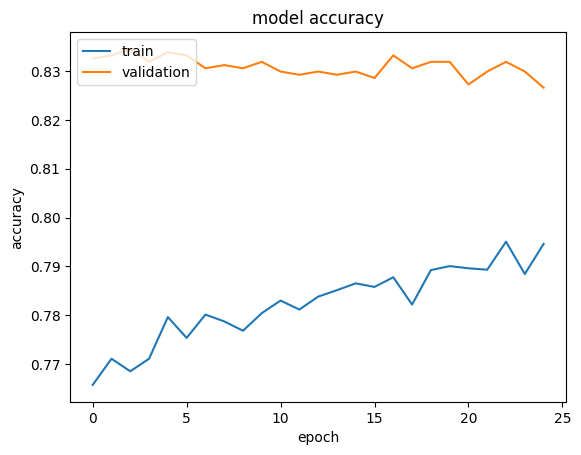

```python
def plot_hist(hist):
    plt.plot(ef_net_model_02.history["accuracy"])
    plt.plot(ef_net_model_02.history["val_accuracy"])
    plt.title("model accuracy")
    plt.ylabel("accuracy")
    plt.xlabel("epoch")
    plt.legend(["train", "validation"], loc="upper left")
    plt.show()


plot_hist(ef_net_model_02)
```

```python
new_efnet_model.evaluate(ef_X_test, (ef_y_test_encoded))
```

```
[0.6131374835968018, 0.75]
```

```python
backend.clear_session()

np.random.seed(1)
import random
random.seed(1)
tf.random.set_seed(1)
```

**Observations and Insights:__**

**Note: You can even go back and build your own architecture on top of the VGG16 Transfer layer and see if you can improve the performance.**

**Think About It:**

- What is your overall performance of these Transfer Learning Architectures? Can we draw a comparison of these models' performances. Are we satisfied with the accuracies that we have received?
- Do you think our issue lies with 'rgb' color_mode?

Now that we have tried multiple pre-trained models, let's build a complex CNN architecture and see if we can get better performance.

# **Facial Emotion Detection - More Complex Neural Network Architecture**

In this section, we will build a more complex Convolutional Neural Network Model that has close to as many parameters as we had in our Transfer Learning Models. However, we will have only 1 input channel for our input images.

### **Creating our Data Loaders**

In this section, we are creating data loaders which we will use as inputs to the more Complicated Convolutional Neural Network. We will go ahead with color_mode = 'grayscale'.

```python
bw_datagen_train  = ImageDataGenerator()
bw_datagen_val = ImageDataGenerator()
bw_datagen_test = ImageDataGenerator()

bw_train_set = bw_datagen_train.flow_from_directory(folder_path + 'train/',
                                              target_size = (IMG_SIZE, IMG_SIZE),
                                              color_mode = "grayscale",
                                              batch_size = 32,
                                              class_mode = 'categorical',
                                              classes = ['happy', 'neutral', 'sad', 'surprise'],
                                              shuffle = True)

bw_validation_set = bw_datagen_val.flow_from_directory(folder_path + 'validation/',
                                              target_size = (IMG_SIZE, IMG_SIZE),
                                              color_mode = "grayscale",
                                              batch_size = 32,
                                              class_mode = 'categorical',
                                              classes = ['happy', 'neutral', 'sad', 'surprise'],
                                              shuffle = True)

bw_test_set = bw_datagen_test.flow_from_directory(folder_path + 'test/',
                                              target_size = (IMG_SIZE, IMG_SIZE),
                                              color_mode = "grayscale",
                                              batch_size = 32,
                                              class_mode = 'categorical',
                                              classes = ['happy', 'neutral', 'sad', 'surprise'],
                                              shuffle = True)
```

```
Found 15109 images belonging to 4 classes.
Found 4977 images belonging to 4 classes.
Found 128 images belonging to 4 classes.
```

### **Model Iteration A Building**

- Try building a model.
- *Iteration A*

```python
# set up the random seeds for reproducability
backend.clear_session()

np.random.seed(1)
import random
random.seed(1)
tf.random.set_seed(1)
```

```python
model_fin_3 = Sequential()

model_fin_3.add(Conv2D(filters = 500, kernel_size = (3, 3), activation = 'relu', padding = "same", input_shape = (IMG_SIZE, IMG_SIZE, 1)))

model_fin_3.add(Conv2D(filters = 500, kernel_size = (3, 3), activation = 'relu', padding = 'same'))

model_fin_3.add(Dropout(0.2))

model_fin_3.add(Conv2D(filters = 500, kernel_size = (3, 3), activation = 'relu', padding = 'same'))

model_fin_3.add(Conv2D(filters = 500, kernel_size = (3, 3), activation = 'relu', padding = 'same'))

model_fin_3.add(Conv2D(filters = 500, kernel_size = (3, 3), activation = 'relu', padding = 'same'))

model_fin_3.add(BatchNormalization())

model_fin_3.add(Conv2D(filters = 256, kernel_size = (3, 3), activation = 'relu', padding = 'same'))

model_fin_3.add(Conv2D(filters = 128, kernel_size = (3, 3), activation = 'relu', padding = 'same'))

model_fin_3.add(BatchNormalization())

model_fin_3.add(MaxPooling2D(pool_size = (2, 2), padding = 'same'))

model_fin_3.add(Conv2D(filters = 128, kernel_size = (3, 3), activation = 'relu', padding = 'same'))

model_fin_3.add(Conv2D(filters = 128, kernel_size = (3, 3), activation = 'relu', padding = 'same'))

model_fin_3.add(BatchNormalization())

model_fin_3.add(Flatten())

model_fin_3.add(Dense(45))

model_fin_3.add(Dense(45))

model_fin_3.add(Dense(45))

model_fin_3.add(Dense(45))

model_fin_3.add(Dense(4, activation = 'softmax'))

opt = Adam(learning_rate = 0.00001)
```

```python
model_fin_3.compile(optimizer = opt, loss = 'categorical_crossentropy', metrics = ['accuracy'])

model_fin_3.summary()
```

```
Model: "sequential_2"
_________________________________________________________________
 Layer (type)                Output Shape              Param #
=================================================================
 conv2d_18 (Conv2D)          (None, 48, 48, 500)       5000

 conv2d_19 (Conv2D)          (None, 48, 48, 500)       2250500

 dropout_2 (Dropout)         (None, 48, 48, 500)       0

 conv2d_20 (Conv2D)          (None, 48, 48, 500)       2250500

 conv2d_21 (Conv2D)          (None, 48, 48, 500)       2250500

 conv2d_22 (Conv2D)          (None, 48, 48, 500)       2250500

 batch_normalization_6 (Bat  (None, 48, 48, 500)       2000
 chNormalization)

 conv2d_23 (Conv2D)          (None, 48, 48, 256)       1152256

 conv2d_24 (Conv2D)          (None, 48, 48, 128)       295040

 batch_normalization_7 (Bat  (None, 48, 48, 128)       512
 chNormalization)

 max_pooling2d_2 (MaxPoolin  (None, 24, 24, 128)       0
 g2D)

 conv2d_25 (Conv2D)          (None, 24, 24, 128)       147584

 conv2d_26 (Conv2D)          (None, 24, 24, 128)       147584

 batch_normalization_8 (Bat  (None, 24, 24, 128)       512
 chNormalization)

 flatten_2 (Flatten)         (None, 73728)             0

 dense_10 (Dense)            (None, 45)                3317805

 dense_11 (Dense)            (None, 45)                2070

 dense_12 (Dense)            (None, 45)                2070

 dense_13 (Dense)            (None, 45)                2070

 dense_14 (Dense)            (None, 4)                 184

=================================================================
Total params: 14076687 (53.70 MB)
Trainable params: 14075175 (53.69 MB)
Non-trainable params: 1512 (5.91 KB)
_________________________________________________________________
```

```python
es = EarlyStopping(monitor = 'val_loss', mode = 'min', verbose = 1, patience = 6)
mc = ModelCheckpoint('best_model_final_redux_3c.h5', monitor = 'val_accuracy', mode = 'max', verbose = 1, save_best_only = True)

final_model_redux_3c = model_fin_3.fit(bw_train_set, epochs = 80, batch_size = 128, validation_data = bw_validation_set, callbacks = [es, mc])
```

```
Epoch 1: val_accuracy improved from -inf to 0.29958, saving model to best_model_final_redux_3c.h5
```

```
Epoch 2: val_accuracy improved from 0.29958 to 0.43259, saving model to best_model_final_redux_3c.h5
Epoch 3: val_accuracy improved from 0.43259 to 0.44585, saving model to best_model_final_redux_3c.h5
Epoch 4: val_accuracy improved from 0.44585 to 0.49970, saving model to best_model_final_redux_3c.h5
Epoch 5: val_accuracy improved from 0.49970 to 0.51597, saving model to best_model_final_redux_3c.h5
Epoch 6: val_accuracy improved from 0.51597 to 0.52622, saving model to best_model_final_redux_3c.h5
Epoch 7: val_accuracy improved from 0.52622 to 0.54551, saving model to best_model_final_redux_3c.h5
Epoch 8: val_accuracy improved from 0.54551 to 0.58368, saving model to best_model_final_redux_3c.h5
Epoch 9: val_accuracy did not improve from 0.58368
Epoch 10: val_accuracy did not improve from 0.58368
Epoch 11: val_accuracy improved from 0.58368 to 0.59634, saving model to best_model_final_redux_3c.h5
Epoch 12: val_accuracy did not improve from 0.59634
Epoch 13: val_accuracy did not improve from 0.59634
Epoch 14: val_accuracy improved from 0.59634 to 0.61021, saving model to best_model_final_redux_3c.h5
Epoch 15: val_accuracy did not improve from 0.61021
Epoch 16: val_accuracy did not improve from 0.61021
Epoch 17: val_accuracy improved from 0.61021 to 0.62025, saving model to best_model_final_redux_3c.h5
Epoch 17: early stopping
```

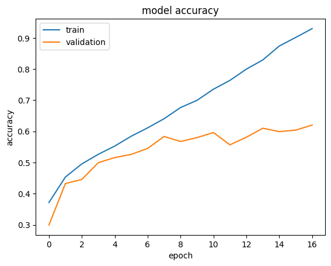

```python
plt.plot(final_model_redux_3c.history['accuracy'])
plt.plot(final_model_redux_3c.history['val_accuracy'])
plt.title('model accuracy')
plt.ylabel('accuracy')
plt.xlabel('epoch')
plt.legend(['train', 'validation'], loc = 'upper left')
plt.show()
```

```python
model_fin_3.evaluate(bw_test_set)
```

```
[1.148941993713379, 0.6171875]
```

#### **Testing 'Best Model' (model_fin) and augmention to the dataset**

```python
bw_datagen_train  = ImageDataGenerator()
bw_datagen_val = ImageDataGenerator()
bw_datagen_test = ImageDataGenerator()

bw_train_set = bw_datagen_train.flow_from_directory(folder_path + 'train/',
                                              target_size = (IMG_SIZE, IMG_SIZE),
                                              color_mode = "grayscale",
                                              batch_size = 32,
                                              class_mode = 'categorical',
                                              classes = ['happy', 'neutral', 'sad', 'surprise'],
                                              shuffle = True)

bw_validation_set = bw_datagen_val.flow_from_directory(folder_path + 'validation/',
                                              target_size = (IMG_SIZE, IMG_SIZE),
                                              color_mode = "grayscale",
                                              batch_size = 32,
                                              class_mode = 'categorical',
                                              classes = ['happy', 'neutral', 'sad', 'surprise'],
                                              shuffle = True)

bw_test_set = bw_datagen_test.flow_from_directory(folder_path + 'test/',
                                              target_size = (IMG_SIZE, IMG_SIZE),
                                              color_mode = "grayscale",
                                              batch_size = 32,
                                              class_mode = 'categorical',
                                              classes = ['happy', 'neutral', 'sad', 'surprise'],
                                              shuffle = True)
```

```
Found 15109 images belonging to 4 classes.
Found 4977 images belonging to 4 classes.
Found 128 images belonging to 4 classes.
```

```python
# create data augmentation variables to use in the model

resize_and_rescale = keras.Sequential([
  layers.Resizing(IMG_SIZE, IMG_SIZE),
  layers.Rescaling(1./255)])

data_augmentation = keras.Sequential([
  layers.RandomFlip("horizontal_and_vertical"),
  layers.RandomRotation(0.4),])
```

```python
# exact same model as the last one execpt this one is using data augmentation in an attempt to boost performances.

aug_model_fin = Sequential([

  layers.Conv2D(filters = 256, kernel_size = (3, 3), activation = 'relu', padding = "same", input_shape = (IMG_SIZE, IMG_SIZE, 1)),

  data_augmentation,

  layers.Conv2D(filters = 256, kernel_size = (3, 3), padding = 'same', activation = 'relu'),

  layers.MaxPooling2D(pool_size = (2, 2), strides = 2, padding = 'same'),

  layers.Conv2D(filters = 256, kernel_size = (3, 3), activation = 'relu', padding = 'same'),

  layers.Conv2D(filters = 256, kernel_size = (3, 3), activation = 'relu', padding = 'same'),

  layers.MaxPooling2D(pool_size = (2, 2), strides = 2, padding = 'same'),

  layers.BatchNormalization(),

  layers.Conv2D(filters = 256, kernel_size = (3, 3), activation = 'relu', padding = 'same'),

  layers.Conv2D(filters = 256, kernel_size = (3, 3), activation = 'relu', padding = 'same'),

  layers.MaxPooling2D(pool_size = (2, 2), strides = 2, padding = 'same'),

  layers.BatchNormalization(),

  layers.Dropout(0.15),

  layers.Conv2D(filters = 256, kernel_size = (3, 3), activation = 'relu', padding = 'same'),

  layers.Conv2D(filters = 256, kernel_size = (3, 3), activation = 'relu', padding = 'same'),

  layers.Conv2D(filters = 128, kernel_size = (3, 3), activation = 'relu', padding = 'same'),

  layers.Conv2D(filters = 128, kernel_size = (3, 3), activation = 'relu', padding = 'same'),

  layers.MaxPooling2D(pool_size = (2, 2), strides = 2, padding = 'same'),

  layers.BatchNormalization(),

  layers.Conv2D(filters = 64, kernel_size = (3, 3), activation = 'relu', padding = 'same'),

  layers.Conv2D(filters = 64, kernel_size = (3, 3), activation = 'relu', padding = 'same'),

  layers.Conv2D(filters = 64, kernel_size = (3, 3), activation = 'relu', padding = 'same'),

  layers.Conv2D(filters = 64, kernel_size = (3, 3), activation = 'relu', padding = 'same'),

  layers.MaxPooling2D(pool_size = (2, 2), padding = 'same'),

  layers.BatchNormalization(),

  layers.Dropout(0.25),

  layers.Conv2D(filters = 64, kernel_size = (3, 3), activation = 'relu', padding = 'same'),

  layers.MaxPooling2D(pool_size = (2, 2), padding = 'same'),

  layers.BatchNormalization(),

  layers.Flatten(),

  layers.Dense(50),

  layers.Dense(50),

  layers.Dense(50),

  layers.Dense(25),

  layers.BatchNormalization(),

  layers.Dense(4, activation = 'softmax'),

])
```

```python
aug_model_fin.compile(optimizer = Adam(learning_rate = 0.00001), loss = 'categorical_crossentropy', metrics = ['accuracy'])
```

```python
aug_model_fin.build(input_shape= (None, IMG_SIZE, IMG_SIZE, 1))

aug_model_fin.summary()
```

```
Model: "sequential_2"
_________________________________________________________________
 Layer (type)                Output Shape              Param #
=================================================================
 conv2d (Conv2D)             (None, 48, 48, 256)       2560

 sequential_1 (Sequential)   (None, 48, 48, 256)       0

 conv2d_1 (Conv2D)           (None, 48, 48, 256)       590080

 max_pooling2d (MaxPooling2  (None, 24, 24, 256)       0
 D)

 conv2d_2 (Conv2D)           (None, 24, 24, 256)       590080

 conv2d_3 (Conv2D)           (None, 24, 24, 256)       590080

 max_pooling2d_1 (MaxPoolin  (None, 12, 12, 256)       0
 g2D)

 batch_normalization (Batch  (None, 12, 12, 256)       1024
 Normalization)

 conv2d_4 (Conv2D)           (None, 12, 12, 256)       590080

 conv2d_5 (Conv2D)           (None, 12, 12, 256)       590080

 max_pooling2d_2 (MaxPoolin  (None, 6, 6, 256)         0
 g2D)

 batch_normalization_1 (Bat  (None, 6, 6, 256)         1024
 chNormalization)

 dropout (Dropout)           (None, 6, 6, 256)         0

 conv2d_6 (Conv2D)           (None, 6, 6, 256)         590080

 conv2d_7 (Conv2D)           (None, 6, 6, 256)         590080

 conv2d_8 (Conv2D)           (None, 6, 6, 128)         295040
```

[output cut: 38 more lines]

```

 dense_2 (Dense)             (None, 50)                2550

 dense_3 (Dense)             (None, 25)                1275

 batch_normalization_5 (Bat  (None, 25)                100
 chNormalization)

 dense_4 (Dense)             (None, 4)                 104

=================================================================
Total params: 4810149 (18.35 MB)
Trainable params: 4808563 (18.34 MB)
Non-trainable params: 1586 (6.20 KB)
_________________________________________________________________
```

```python
es = EarlyStopping(monitor = 'val_loss', mode = 'min', verbose = 1, patience = 5)
mc = ModelCheckpoint('best_aug_model.h5', monitor = 'val_accuracy', mode = 'max', verbose = 1, save_best_only = True)
```

```python
final_aug_model = aug_model_fin.fit(bw_train_set, epochs = 60, batch_size = 64, validation_data = bw_validation_set, callbacks = [es, mc])
```

```
Epoch 1: val_accuracy improved from -inf to 0.32329, saving model to best_aug_model.h5
```

```
Epoch 2: val_accuracy improved from 0.32329 to 0.32731, saving model to best_aug_model.h5
Epoch 3: val_accuracy improved from 0.32731 to 0.32952, saving model to best_aug_model.h5
Epoch 4: val_accuracy improved from 0.32952 to 0.35483, saving model to best_aug_model.h5
Epoch 5: val_accuracy did not improve from 0.35483
Epoch 6: val_accuracy did not improve from 0.35483
Epoch 7: val_accuracy did not improve from 0.35483
Epoch 8: val_accuracy did not improve from 0.35483
Epoch 9: val_accuracy did not improve from 0.35483
Epoch 10: val_accuracy did not improve from 0.35483
Epoch 11: val_accuracy did not improve from 0.35483
Epoch 12: val_accuracy did not improve from 0.35483
Epoch 13: val_accuracy did not improve from 0.35483
Epoch 13: early stopping
```

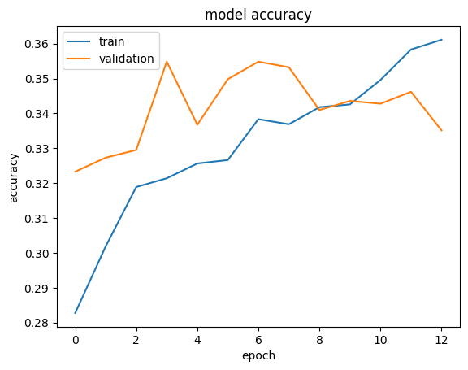

```python
plt.plot(final_aug_model.history['accuracy'])
plt.plot(final_aug_model.history['val_accuracy'])
plt.title('model accuracy')
plt.ylabel('accuracy')
plt.xlabel('epoch')
plt.legend(['train', 'validation'], loc = 'upper left')
plt.show()
```

```python
aug_model_fin.evaluate(bw_test_set)
```

```
[1.309892177581787, 0.421875]
```

**Observations & Insights:__**

- I am not certain the data augmentation was applied effectively. The model's performance is significantly reduced.
- Performance on the validation set is very unstable, perhaps the data augmentations produced such chaotic accuracy readings.
- Experiment didnt not achieve its goal of improving but interesting insights about the model's performance on validation data after some augmentations were found.